# Read Counting

Carson Stacy & Jeffrey Lewis

Fall 2023

last updated: 2023-08-24

As usual, make sure we have the right packages for this exercise

```r
if (!require("pacman")) install.packages("pacman"); library(pacman)
# let's load all of the files we were using and want to have again today
p_load("tidyverse", "knitr", "readr",
       "pander", "BiocManager",
       "dplyr", "stringr")

# We also need the Bioconductor packages "Rsubread" for today's activity.
p_load("Rsubread")
```

Previously, we aligned our fastq files to the reference genome, generating BAM files. They should be in your “~/Desktop/Genomic_Data_Analysis/Data/Trimmed_rfastp” folder, unless you chose a different place to store them.

```r
# Where the bam files are located (default same as trimmed fastq file location)
bam_file_dir <- "~/Desktop/Genomic_Data_Analysis/Data/Trimmed_rfastp/"

# save list of all of those files with their full path
bam.files <- list.files(path = bam_file_dir,
                                  pattern = ".subread.BAM$",
                                  full.names = TRUE)
# make sure we see what we expect.
bam.files
```

```
##  [1] "/Users/clstacy/Desktop/Genomic_Data_Analysis/Data/Trimmed_rfastp//YPS606_MSN24_ETOH_REP1_R1.fastq.gz.subread.BAM"
##  [2] "/Users/clstacy/Desktop/Genomic_Data_Analysis/Data/Trimmed_rfastp//YPS606_MSN24_ETOH_REP2_R1.fastq.gz.subread.BAM"
##  [3] "/Users/clstacy/Desktop/Genomic_Data_Analysis/Data/Trimmed_rfastp//YPS606_MSN24_ETOH_REP3_R1.fastq.gz.subread.BAM"
##  [4] "/Users/clstacy/Desktop/Genomic_Data_Analysis/Data/Trimmed_rfastp//YPS606_MSN24_ETOH_REP4_R1.fastq.gz.subread.BAM"
##  [5] "/Users/clstacy/Desktop/Genomic_Data_Analysis/Data/Trimmed_rfastp//YPS606_MSN24_MOCK_REP1_R1.fastq.gz.subread.BAM"
##  [6] "/Users/clstacy/Desktop/Genomic_Data_Analysis/Data/Trimmed_rfastp//YPS606_MSN24_MOCK_REP2_R1.fastq.gz.subread.BAM"
##  [7] "/Users/clstacy/Desktop/Genomic_Data_Analysis/Data/Trimmed_rfastp//YPS606_MSN24_MOCK_REP3_R1.fastq.gz.subread.BAM"
##  [8] "/Users/clstacy/Desktop/Genomic_Data_Analysis/Data/Trimmed_rfastp//YPS606_MSN24_MOCK_REP4_R1.fastq.gz.subread.BAM"
##  [9] "/Users/clstacy/Desktop/Genomic_Data_Analysis/Data/Trimmed_rfastp//YPS606_WT_ETOH_REP1_R1.fastq.gz.subread.BAM"
## [10] "/Users/clstacy/Desktop/Genomic_Data_Analysis/Data/Trimmed_rfastp//YPS606_WT_ETOH_REP2_R1.fastq.gz.subread.BAM"
## [11] "/Users/clstacy/Desktop/Genomic_Data_Analysis/Data/Trimmed_rfastp//YPS606_WT_ETOH_REP3_R1.fastq.gz.subread.BAM"
## [12] "/Users/clstacy/Desktop/Genomic_Data_Analysis/Data/Trimmed_rfastp//YPS606_WT_ETOH_REP4_R1.fastq.gz.subread.BAM"
## [13] "/Users/clstacy/Desktop/Genomic_Data_Analysis/Data/Trimmed_rfastp//YPS606_WT_MOCK_REP1_R1.fastq.gz.subread.BAM"
## [14] "/Users/clstacy/Desktop/Genomic_Data_Analysis/Data/Trimmed_rfastp//YPS606_WT_MOCK_REP2_R1.fastq.gz.subread.BAM"
## [15] "/Users/clstacy/Desktop/Genomic_Data_Analysis/Data/Trimmed_rfastp//YPS606_WT_MOCK_REP3_R1.fastq.gz.subread.BAM"
## [16] "/Users/clstacy/Desktop/Genomic_Data_Analysis/Data/Trimmed_rfastp//YPS606_WT_MOCK_REP4_R1.fastq.gz.subread.BAM"
```

You should see the full paths to all 16 trimmed fastq bam files that we will be mapping to the reference genome today.

# Read Counting

We currently have our raw reads mapped to the genome in the form of bam files. Before the differential expression analysis can proceed, these reads must be assigned and counted towards annotated genes. This can be achieved with functions in the Rsubread package, we all also see how to do this with Salmon.

## Retrieve the genome annotation

We will use a bash code chunk to download the latest genome annotation

```bash
# Define the destination file path
REF_DIR="/Users/$USER/Desktop/Genomic_Data_Analysis/Reference"
# If this directory doesn't exist, you need to first complete the Read_Mapping.Rmd exercise.

# Define the URL of reference genome annotation (gtf)
# (latest from ensembl)
url="ftp://ftp.ensembl.org/pub/release-110/gtf/saccharomyces_cerevisiae/Saccharomyces_cerevisiae.R64-1-1.110.gtf.gz"

# Check if the file already exists at the destination location
if [ ! -f "$REF_DIR/Saccharomyces_cerevisiae.R64-1-1.110.gtf.gz" ]; then
    echo "Reference genome annotation not found, downloading..."
    # If the file does not exist, download it using curl
    curl -o "$REF_DIR/Saccharomyces_cerevisiae.R64-1-1.110.gtf.gz" "$url"
    echo "Downloading finished"
else
    echo "File already exists at $REF_DIR Skipping download."
fi
```

```
## File already exists at /Users/clstacy/Desktop/Genomic_Data_Analysis/Reference Skipping download.
```

Let’s take a look at the first few lines of the gtf file

```r
# see the header columns with metadata starting with #! and delimited with \t
read_csv("~/Desktop/Genomic_Data_Analysis/Reference/Saccharomyces_cerevisiae.R64-1-1.110.gtf.gz",
    col_names = FALSE) %>% head(10)
```

```
## # A tibble: 10 × 1
##    X1
##    <chr>
##  1 "#!genome-build R64-1-1"
##  2 "#!genome-version R64-1-1"
##  3 "#!genome-date 2011-09"
##  4 "#!genome-build-accession GCA_000146045.2"
##  5 "#!genebuild-last-updated 2018-10"
##  6 "IV\tsgd\tgene\t8683\t9756\t.\t-\t.\tgene_id \"YDL246C\"; gene_name \"SOR2\"…
##  7 "IV\tsgd\ttranscript\t8683\t9756\t.\t-\t.\tgene_id \"YDL246C\"; transcript_i…
##  8 "IV\tsgd\texon\t8683\t9756\t.\t-\t.\tgene_id \"YDL246C\"; transcript_id \"YD…
##  9 "IV\tsgd\tCDS\t8686\t9756\t.\t-\t0\tgene_id \"YDL246C\"; transcript_id \"YDL…
## 10 "IV\tsgd\tstart_codon\t9754\t9756\t.\t-\t0\tgene_id \"YDL246C\"; transcript_…
```

```r
# We can also take a look at the first few entries to see the columns
read_tsv("~/Desktop/Genomic_Data_Analysis/Reference/Saccharomyces_cerevisiae.R64-1-1.110.gtf.gz",
    col_names = FALSE,  comment = "#", trim_ws = TRUE) %>% head(20)
```

```
## # A tibble: 20 × 9
##    X1    X2    X3               X4      X5 X6    X7    X8    X9
##    <chr> <chr> <chr>         <dbl>   <dbl> <chr> <chr> <chr> <chr>
##  1 IV    sgd   gene           8683    9756 .     -     .     "gene_id \"YDL246C…
##  2 IV    sgd   transcript     8683    9756 .     -     .     "gene_id \"YDL246C…
##  3 IV    sgd   exon           8683    9756 .     -     .     "gene_id \"YDL246C…
##  4 IV    sgd   CDS            8686    9756 .     -     0     "gene_id \"YDL246C…
##  5 IV    sgd   start_codon    9754    9756 .     -     0     "gene_id \"YDL246C…
##  6 IV    sgd   stop_codon     8683    8685 .     -     0     "gene_id \"YDL246C…
##  7 IV    sgd   gene          17577   18566 .     -     .     "gene_id \"YDL243C…
##  8 IV    sgd   transcript    17577   18566 .     -     .     "gene_id \"YDL243C…
##  9 IV    sgd   exon          17577   18566 .     -     .     "gene_id \"YDL243C…
## 10 IV    sgd   CDS           17580   18566 .     -     0     "gene_id \"YDL243C…
## 11 IV    sgd   start_codon   18564   18566 .     -     0     "gene_id \"YDL243C…
## 12 IV    sgd   stop_codon    17577   17579 .     -     0     "gene_id \"YDL243C…
## 13 IV    sgd   gene        1248154 1249821 .     -     .     "gene_id \"YDR387C…
## 14 IV    sgd   transcript  1248154 1249821 .     -     .     "gene_id \"YDR387C…
## 15 IV    sgd   exon        1248154 1249821 .     -     .     "gene_id \"YDR387C…
## 16 IV    sgd   CDS         1248157 1249821 .     -     0     "gene_id \"YDR387C…
## 17 IV    sgd   start_codon 1249819 1249821 .     -     0     "gene_id \"YDR387C…
## 18 IV    sgd   stop_codon  1248154 1248156 .     -     0     "gene_id \"YDR387C…
## 19 IV    sgd   gene         289572  290081 .     -     .     "gene_id \"YDL094C…
## 20 IV    sgd   transcript   289572  290081 .     -     .     "gene_id \"YDL094C…
```

There are 9 columns in a standard gtf file, information about each is available here: https://useast.ensembl.org/info/website/upload/gff.html

Note that version 2 of gff is identical to the gtf format.

## Counting with FeatureCounts

```r
library(Rsubread)

# Set path of the reference annotation gzipped gtf file
reference_annotation = "~/Desktop/Genomic_Data_Analysis/Reference/Saccharomyces_cerevisiae.R64-1-1.110.gtf.gz"
```

```r
args(featureCounts)
```

```
## function (files, annot.inbuilt = "mm39", annot.ext = NULL, isGTFAnnotationFile = FALSE,
##     GTF.featureType = "exon", GTF.attrType = "gene_id", GTF.attrType.extra = NULL,
##     chrAliases = NULL, useMetaFeatures = TRUE, allowMultiOverlap = FALSE,
##     minOverlap = 1, fracOverlap = 0, fracOverlapFeature = 0,
##     largestOverlap = FALSE, nonOverlap = NULL, nonOverlapFeature = NULL,
##     readShiftType = "upstream", readShiftSize = 0, readExtension5 = 0,
##     readExtension3 = 0, read2pos = NULL, countMultiMappingReads = TRUE,
##     fraction = FALSE, isLongRead = FALSE, minMQS = 0, splitOnly = FALSE,
##     nonSplitOnly = FALSE, primaryOnly = FALSE, ignoreDup = FALSE,
##     strandSpecific = 0, juncCounts = FALSE, genome = NULL, isPairedEnd = FALSE,
##     countReadPairs = TRUE, requireBothEndsMapped = FALSE, checkFragLength = FALSE,
##     minFragLength = 50, maxFragLength = 600, countChimericFragments = TRUE,
##     autosort = TRUE, nthreads = 1, byReadGroup = FALSE, reportReads = NULL,
##     reportReadsPath = NULL, maxMOp = 10, tmpDir = ".", verbose = FALSE)
## NULL
```

The Phred offset determines the encoding for the base-calling quality string in the FASTQ file. For the Illumina 1.8 format onwards, this encoding is set at +33. However, older formats may use a +64 encoding. Users should ensure that the correct encoding is specified during alignment. If unsure, one can examine the first several quality strings in the FASTQ file. A good rule of thumb is to check whether lower-case letters are present (+64 encoding) or absent (+33).

```r
# This command counts the number of each feature per fastq file,
#.  generating an output we can use later.
fc <- featureCounts(bam.files,
                    annot.ext = reference_annotation,
                    isGTFAnnotationFile = TRUE,
                    GTF.featureType = "exon"
                    )
```

```
##
##         ==========     _____ _    _ ____  _____  ______          _____
##         =====         / ____| |  | |  _ \|  __ \|  ____|   /\   |  __ \
##           =====      | (___ | |  | | |_) | |__) | |__     /  \  | |  | |
##             ====      \___ \| |  | |  _ <|  _  /|  __|   / /\ \ | |  | |
##               ====    ____) | |__| | |_) | | \ \| |____ / ____ \| |__| |
##         ==========   |_____/ \____/|____/|_|  \_\______/_/    \_\_____/
##        Rsubread 2.12.3
##
## //========================== featureCounts setting ===========================\\
## ||                                                                            ||
## ||             Input files : 16 BAM files                                     ||
## ||                                                                            ||
## ||                           YPS606_MSN24_ETOH_REP1_R1.fastq.gz.subread.BAM   ||
## ||                           YPS606_MSN24_ETOH_REP2_R1.fastq.gz.subread.BAM   ||
## ||                           YPS606_MSN24_ETOH_REP3_R1.fastq.gz.subread.BAM   ||
## ||                           YPS606_MSN24_ETOH_REP4_R1.fastq.gz.subread.BAM   ||
## ||                           YPS606_MSN24_MOCK_REP1_R1.fastq.gz.subread.BAM   ||
## ||                           YPS606_MSN24_MOCK_REP2_R1.fastq.gz.subread.BAM   ||
## ||                           YPS606_MSN24_MOCK_REP3_R1.fastq.gz.subread.BAM   ||
## ||                           YPS606_MSN24_MOCK_REP4_R1.fastq.gz.subread.BAM   ||
## ||                           YPS606_WT_ETOH_REP1_R1.fastq.gz.subread.BAM      ||
## ||                           YPS606_WT_ETOH_REP2_R1.fastq.gz.subread.BAM      ||
## ||                           YPS606_WT_ETOH_REP3_R1.fastq.gz.subread.BAM      ||
## ||                           YPS606_WT_ETOH_REP4_R1.fastq.gz.subread.BAM      ||
## ||                           YPS606_WT_MOCK_REP1_R1.fastq.gz.subread.BAM      ||
## ||                           YPS606_WT_MOCK_REP2_R1.fastq.gz.subread.BAM      ||
## ||                           YPS606_WT_MOCK_REP3_R1.fastq.gz.subread.BAM      ||
## ||                           YPS606_WT_MOCK_REP4_R1.fastq.gz.subread.BAM      ||
## ||                                                                            ||
## ||              Paired-end : no                                               ||
## ||        Count read pairs : no                                               ||
## ||              Annotation : Saccharomyces_cerevisiae.R64-1-1.110.gtf.gz  ... ||
## ||      Dir for temp files : .                                                ||
## ||                 Threads : 1                                                ||
## ||                   Level : meta-feature level                               ||
## ||      Multimapping reads : counted                                          ||
## || Multi-overlapping reads : not counted                                      ||
## ||   Min overlapping bases : 1                                                ||
## ||                                                                            ||
```

[output cut: 94 more lines]

```
## ||    Single-end reads are included.                                          ||
## ||    Total alignments : 224767                                               ||
## ||    Successfully assigned alignments : 184436 (82.1%)                       ||
## ||    Running time : 0.00 minutes                                             ||
## ||                                                                            ||
## || Process BAM file YPS606_WT_MOCK_REP4_R1.fastq.gz.subread.BAM...            ||
## ||    Single-end reads are included.                                          ||
## ||    Total alignments : 206865                                               ||
## ||    Successfully assigned alignments : 172568 (83.4%)                       ||
## ||    Running time : 0.00 minutes                                             ||
## ||                                                                            ||
## || Write the final count table.                                               ||
## || Write the read assignment summary.                                         ||
## ||                                                                            ||
## \\============================================================================//
```

We can see what all is stored in the featureCounts output object

```r
names(fc)
```

```
## [1] "counts"     "annotation" "targets"    "stat"
```

The statistics of the read mapping can be seen with `fc$stats`. This reports the numbers of unassigned reads and the reasons why they are not assigned (eg. ambiguity, multi-mapping, secondary alignment, mapping quality, fragment length, chimera, read duplicate, non-junction and so on), in addition to the number of successfully assigned reads for each library.

```r
fc$stat
```

```
##                           Status YPS606_MSN24_ETOH_REP1_R1.fastq.gz.subread.BAM
## 1                       Assigned                                         195105
## 2            Unassigned_Unmapped                                           5358
## 3           Unassigned_Read_Type                                              0
## 4           Unassigned_Singleton                                              0
## 5      Unassigned_MappingQuality                                              0
## 6             Unassigned_Chimera                                              0
## 7      Unassigned_FragmentLength                                              0
## 8           Unassigned_Duplicate                                              0
## 9        Unassigned_MultiMapping                                              0
## 10          Unassigned_Secondary                                              0
## 11           Unassigned_NonSplit                                              0
## 12         Unassigned_NoFeatures                                          16917
## 13 Unassigned_Overlapping_Length                                              0
## 14          Unassigned_Ambiguity                                          15898
```

[output cut: 225 more lines]

## Counts

The counts for the samples are stored in fc$counts.

We can look at the dimensions of the counts to see how many genes and samples are present. The first number is the number of genes and the second number is the number of samples.

```r
dim(fc$counts)
```

```
## [1] 7127   16
```

let’s take a look at the first few lines of fc$counts

```r
head(fc$counts)
```

```
##         YPS606_MSN24_ETOH_REP1_R1.fastq.gz.subread.BAM
## YDL246C                                              0
## YDL243C                                              2
## YDR387C                                              6
## YDL094C                                              4
## YDR438W                                              5
## YDR523C                                              1
##         YPS606_MSN24_ETOH_REP2_R1.fastq.gz.subread.BAM
## YDL246C                                              0
## YDL243C                                              1
## YDR387C                                             10
## YDL094C                                              5
## YDR438W                                              6
## YDR523C                                              1
##         YPS606_MSN24_ETOH_REP3_R1.fastq.gz.subread.BAM
## YDL246C                                              0
## YDL243C                                              1
## YDR387C                                              7
## YDL094C                                              7
## YDR438W                                              5
## YDR523C                                              0
##         YPS606_MSN24_ETOH_REP4_R1.fastq.gz.subread.BAM
## YDL246C                                              0
## YDL243C                                              4
## YDR387C                                              6
## YDL094C                                              4
## YDR438W                                              3
## YDR523C                                              0
##         YPS606_MSN24_MOCK_REP1_R1.fastq.gz.subread.BAM
## YDL246C                                              0
## YDL243C                                              1
## YDR387C                                              1
## YDL094C                                              3
## YDR438W                                              4
## YDR523C                                              0
##         YPS606_MSN24_MOCK_REP2_R1.fastq.gz.subread.BAM
## YDL246C                                              0
## YDL243C                                              1
## YDR387C                                              3
## YDL094C                                              1
```

[output cut: 57 more lines]

```
## YDR523C                                           0
##         YPS606_WT_MOCK_REP3_R1.fastq.gz.subread.BAM
## YDL246C                                           0
## YDL243C                                           1
## YDR387C                                           9
## YDL094C                                           6
## YDR438W                                           2
## YDR523C                                           0
##         YPS606_WT_MOCK_REP4_R1.fastq.gz.subread.BAM
## YDL246C                                           0
## YDL243C                                           0
## YDR387C                                           6
## YDL094C                                           5
## YDR438W                                           4
## YDR523C                                           0
```

The row names of the fc$counts matrix represent the Systematic Name for each gene (can be Entrez gene identifiers for other organisms) and the column names are the output filenames from calling the align function.

The annotation slot shows the annotation information that featureCounts used to summarise reads over genes.

```r
head(fc$annotation)
```

```
##    GeneID Chr   Start     End Strand Length
## 1 YDL246C  IV    8683    9756      -   1074
## 2 YDL243C  IV   17577   18566      -    990
## 3 YDR387C  IV 1248154 1249821      -   1668
## 4 YDL094C  IV  289572  290081      -    510
## 5 YDR438W  IV 1338274 1339386      +   1113
## 6 YDR523C  IV 1485566 1487038      -   1473
```

# Saving `fc` object for future use

We will need to use this object in our next class. We can use the R function `saveRDS()` to save the R object to your computer, so it can be accessed at a later date.

```r
# create a directory for the count output to go into if not already present
dir_output_counts <- path.expand("~/Desktop/Genomic_Data_Analysis/Data/Counts/Rsubread/")
if (!dir.exists(dir_output_counts)) {dir.create(dir_output_counts, recursive = TRUE)}

# save the R data object
saveRDS(object = fc, file = paste0(dir_output_counts,"rsubread.yeast_fc_output.Rds"))

# often, we want to share this file as a tsv file. Here is how we can do that:
write_tsv(data.frame(
            fc$annotation[,"GeneID"],
            fc$counts,
            stringsAsFactors=FALSE),
    file=paste0(dir_output_counts,"rsubread.gene_counts.merged.yeast.tsv"))
```

## RSubread also allows for some basic QC checking:

We can have a look at the quality scores associated with each base that has been called by the sequencing machine using the qualityScores function in Rsubread.

Let’s extract quality scores for 50 reads for the fastq file .

```r
# Extract quality scores
qs <- qualityScores(
  filename="~/Desktop/Genomic_Data_Analysis/Data/Trimmed_rfastp/YPS606_MSN24_ETOH_REP1_R1.fastq.gz",
                    nreads=50)
```

```
##
## qualityScores Rsubread 2.12.3
##
## Scan the input file...
## Totally 233278 reads were scanned; the sampling interval is 4665.
## Now extract read quality information...
##
## Completed successfully. Quality scores for 50 reads (equally spaced in the file) are returned.
```

```r
head(qs)
```

```
##       1  2  3  4  5  6  7  8  9 10 11 12 13 14 15 16 17 18 19 20 21 22 23 24 25
## [1,] 32 32 37 37 37 41 41 41 37 41 41 41 41 41 41 41 41 41 41 41 41 41 41 41 41
## [2,] 32 32 37 37 37 41 41 41 41 41 41 41 37 41 41 41 41 41 41 41 41 41 41 41 41
## [3,] 32 32 37 37 37 41 41 41 41 41 37 41 41 37 41 41 41 37 41 41 41 41 41 41 41
## [4,] 32 32 37 37 37 41 41 41 41 41 41 41 41 41 41 41 41 41 41 41 41 41 41 41 41
## [5,] 32 32 37 37 37 41 41 41 41 41 41 41 41 41 41 41 41 41 41 41 41 41 41 41 41
## [6,] 32 32 37 37 37 41 41 41 41 41 41 27 37 41 41 41 41 41 41 41 41 41 41 41 41
##      26 27 28 29 30 31 32 33 34 35 36 37 38 39 40 41 42 43 44 45 46 47 48 49 50
## [1,] 41 41 41 41 41 41 41 41 41 41 41 41 41 41 41 41 41 41 41 41 41 41 41 41 41
## [2,] 41 41 41 41 41 41 41 41 41 41 41 41 41 41 41 41 41 41 41 41 41 41 41 41 41
## [3,] 41 41 41 41 41 41 41 41 41 41 41 41 41 41 37 41 41 41 41 41 41 41 41 41 41
## [4,] 41 41 41 41 41 41 41 41 41 41 41 41 41 41 41 41 41 41 41 41 41 41 41 41 41
## [5,] 41 41 41 41 41 41 41 41 41 41 41 41 41 41 41 41 41 41 41 41 41 41 41 41 41
## [6,] 41 41 41 41 37 41 41 41 41 41 41 41 41 41 41 41 41 41 41 41 41 41 41 41 41
```

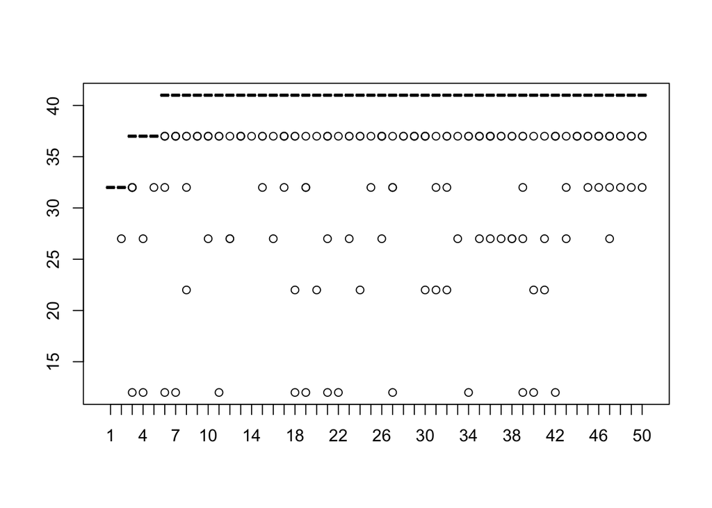

```r
boxplot(qs)
```

# Salmon

Let’s go through using salmon to count reads directly from the trimmed fastq.gz files

## Pseudomapping & counting

```bash
DATA_DIR="/Users/$USER/Desktop/Genomic_Data_Analysis/Data/Trimmed_rfastp"
SALMON_OUT_DIR="/Users/$USER/Desktop/Genomic_Data_Analysis/Data/Counts/Salmon"
SALMON_INDEX_DIR="/Users/$USER/Desktop/Genomic_Data_Analysis/Reference/index_salmon_Saccharomyces_cerevisiae.R64-1-1"

# make the analysis directory if it doesn't already exist
mkdir -p $SALMON_OUT_DIR

# activate the salmon environment
conda activate salmon

# loop through all of the fastq files
for fn in $DATA_DIR/*.fastq.gz;
do
samp=`basename ${fn}`
echo "Processing sample ${samp}"

# run salmon
salmon quant -i $SALMON_INDEX_DIR -l A \
         -r ${fn} \
         --useVBOpt \
         -p 4 --validateMappings -o $SALMON_OUT_DIR/${samp}_quant
done

# combine all of the output files into a merged count matrix
salmon quantmerge --quants $SALMON_OUT_DIR/*_quant --column numreads -o $SALMON_OUT_DIR/salmon.gene_counts.merged.yeast.tsv

# remove the _mRNA from gene name
sed -i '' -E 's/^([^\t]+)_mRNA(\t|$)/\1\2/' $SALMON_OUT_DIR/salmon.gene_counts.merged.yeast.tsv

# we can also create a table of tpm values per gene by changing the --column flag
salmon quantmerge --quants $SALMON_OUT_DIR/*_quant --column tpm \
          -o $SALMON_OUT_DIR/salmon.gene_tpm.merged.yeast.tsv

# remove the _mRNA from gene name
sed -i '' -E 's/^([^\t]+)_mRNA(\t|$)/\1\2/' $SALMON_OUT_DIR/salmon.gene_tpm.merged.yeast.tsv

conda deactivate
```

[output not shown]

[output cut: 1546 more lines]

```
## [2023-08-24 10:14:53.853] [mergeLog] [info] Parsing /Users/clstacy/Desktop/Genomic_Data_Analysis/Data/Counts/Salmon/YPS606_MSN24_ETOH_REP2_R1.fastq.gz_quant/quant.sf
## [2023-08-24 10:14:53.861] [mergeLog] [info] Parsing /Users/clstacy/Desktop/Genomic_Data_Analysis/Data/Counts/Salmon/YPS606_MSN24_ETOH_REP3_R1.fastq.gz_quant/quant.sf
## [2023-08-24 10:14:53.869] [mergeLog] [info] Parsing /Users/clstacy/Desktop/Genomic_Data_Analysis/Data/Counts/Salmon/YPS606_MSN24_ETOH_REP4_R1.fastq.gz_quant/quant.sf
## [2023-08-24 10:14:53.876] [mergeLog] [info] Parsing /Users/clstacy/Desktop/Genomic_Data_Analysis/Data/Counts/Salmon/YPS606_MSN24_MOCK_REP1_R1.fastq.gz_quant/quant.sf
## [2023-08-24 10:14:53.883] [mergeLog] [info] Parsing /Users/clstacy/Desktop/Genomic_Data_Analysis/Data/Counts/Salmon/YPS606_MSN24_MOCK_REP2_R1.fastq.gz_quant/quant.sf
## [2023-08-24 10:14:53.891] [mergeLog] [info] Parsing /Users/clstacy/Desktop/Genomic_Data_Analysis/Data/Counts/Salmon/YPS606_MSN24_MOCK_REP3_R1.fastq.gz_quant/quant.sf
## [2023-08-24 10:14:53.898] [mergeLog] [info] Parsing /Users/clstacy/Desktop/Genomic_Data_Analysis/Data/Counts/Salmon/YPS606_MSN24_MOCK_REP4_R1.fastq.gz_quant/quant.sf
## [2023-08-24 10:14:53.905] [mergeLog] [info] Parsing /Users/clstacy/Desktop/Genomic_Data_Analysis/Data/Counts/Salmon/YPS606_WT_ETOH_REP1_R1.fastq.gz_quant/quant.sf
## [2023-08-24 10:14:53.913] [mergeLog] [info] Parsing /Users/clstacy/Desktop/Genomic_Data_Analysis/Data/Counts/Salmon/YPS606_WT_ETOH_REP2_R1.fastq.gz_quant/quant.sf
## [2023-08-24 10:14:53.920] [mergeLog] [info] Parsing /Users/clstacy/Desktop/Genomic_Data_Analysis/Data/Counts/Salmon/YPS606_WT_ETOH_REP3_R1.fastq.gz_quant/quant.sf
## [2023-08-24 10:14:53.927] [mergeLog] [info] Parsing /Users/clstacy/Desktop/Genomic_Data_Analysis/Data/Counts/Salmon/YPS606_WT_ETOH_REP4_R1.fastq.gz_quant/quant.sf
## [2023-08-24 10:14:53.934] [mergeLog] [info] Parsing /Users/clstacy/Desktop/Genomic_Data_Analysis/Data/Counts/Salmon/YPS606_WT_MOCK_REP1_R1.fastq.gz_quant/quant.sf
## [2023-08-24 10:14:53.941] [mergeLog] [info] Parsing /Users/clstacy/Desktop/Genomic_Data_Analysis/Data/Counts/Salmon/YPS606_WT_MOCK_REP2_R1.fastq.gz_quant/quant.sf
## [2023-08-24 10:14:53.948] [mergeLog] [info] Parsing /Users/clstacy/Desktop/Genomic_Data_Analysis/Data/Counts/Salmon/YPS606_WT_MOCK_REP3_R1.fastq.gz_quant/quant.sf
## [2023-08-24 10:14:53.956] [mergeLog] [info] Parsing /Users/clstacy/Desktop/Genomic_Data_Analysis/Data/Counts/Salmon/YPS606_WT_MOCK_REP4_R1.fastq.gz_quant/quant.sf
```

This script loops through each sample and invokes salmon using default mostly options. The `-i` argument tells salmon where to find the index `-l A` tells salmon that it should automatically determine the library type of the sequencing reads (e.g. stranded vs. unstranded etc.). The -r arguments tell salmon where to find the SE reads for this sample (notice, salmon will accept gzipped FASTQ files directly). Finally, the `-p 4` argument tells salmon to make use of 4 threads and the `-o` argument specifies the directory where salmon’s quantification results should be written. The `–useVBOpt` flag sets to use variational Bayesian EM algorithm rather than the ‘standard EM’ to optimize abundance estimates (more accurate). Salmon exposes many different options to the user that enable extra features or modify default behavior. However, the purpose and behavior of all of those options is beyond the scope of this introductory tutorial. You can read about salmon’s many options in the documentation.

# Activity

1. Identify which gene has the highest counts across all samples for both salmon and Rsubread outputs.
2. Redo the counting over the exons, rather than the genes (specify useMetaFeatures = FALSE) with RSubread. Use the bam files generated doing alignment reporting only unique reads, and call the featureCounts object fc.exon. Check the dimension of the counts slot to see how much larger it is.
3. What differences do you notice in the count values from Salmon vs Rsubread?

Be sure to knit this file into a pdf or html file once you’re finished.

**R version 4.2.2 (2022-10-31)**

**Platform:** aarch64-apple-darwin20 (64-bit)

**locale:** en_US.UTF-8||en_US.UTF-8||en_US.UTF-8||C||en_US.UTF-8||en_US.UTF-8

**attached base packages:** *stats*, *graphics*, *grDevices*, *utils*, *datasets*, *methods* and *base*

**other attached packages:** *Rsubread(v.2.12.3)*, *BiocManager(v.1.30.21.1)*, *pander(v.0.6.5)*, *knitr(v.1.43)*, *lubridate(v.1.9.2)*, *forcats(v.1.0.0)*, *stringr(v.1.5.0)*, *dplyr(v.1.1.2)*, *purrr(v.1.0.1)*, *readr(v.2.1.4)*, *tidyr(v.1.3.0)*, *tibble(v.3.2.1)*, *ggplot2(v.3.4.2)*, *tidyverse(v.2.0.0)* and *pacman(v.0.5.1)*

**loaded via a namespace (and not attached):** *tidyselect(v.1.2.0)*, *xfun(v.0.39)*, *bslib(v.0.5.0)*, *lattice(v.0.21-8)*, *colorspace(v.2.1-0)*, *vctrs(v.0.6.3)*, *generics(v.0.1.3)*, *htmltools(v.0.5.5)*, *yaml(v.2.3.7)*, *utf8(v.1.2.3)*, *rlang(v.1.1.1)*, *jquerylib(v.0.1.4)*, *pillar(v.1.9.0)*, *glue(v.1.6.2)*, *withr(v.2.5.0)*, *bit64(v.4.0.5)*, *lifecycle(v.1.0.3)*, *munsell(v.0.5.0)*, *gtable(v.0.3.3)*, *codetools(v.0.2-19)*, *evaluate(v.0.21)*, *tzdb(v.0.4.0)*, *fastmap(v.1.1.1)*, *parallel(v.4.2.2)*, *fansi(v.1.0.4)*, *highr(v.0.10)*, *Rcpp(v.1.0.11)*, *scales(v.1.2.1)*, *cachem(v.1.0.8)*, *vroom(v.1.6.3)*, *jsonlite(v.1.8.7)*, *bit(v.4.0.5)*, *hms(v.1.1.3)*, *digest(v.0.6.33)*, *stringi(v.1.7.12)*, *grid(v.4.2.2)*, *cli(v.3.6.1)*, *tools(v.4.2.2)*, *magrittr(v.2.0.3)*, *sass(v.0.4.7)*, *crayon(v.1.5.2)*, *pkgconfig(v.2.0.3)*, *Matrix(v.1.6-0)*, *timechange(v.0.2.0)*, *rmarkdown(v.2.23)*, *rstudioapi(v.0.15.0)*, *R6(v.2.5.1)* and *compiler(v.4.2.2)*